# Performing a Ridge Regression

Running a ridge regression using the glmnet function with alpha=0

First we must load the data. For this we will use some default baseball statistics.

```r
library(ISLR)
View(Hitters)
names(Hitters)
```

```
 [1] "AtBat"     "Hits"      "HmRun"     "Runs"      "RBI"       "Walks"     "Years"     "CAtBat"
 [9] "CHits"     "CHmRun"    "CRuns"     "CRBI"      "CWalks"    "League"    "Division"  "PutOuts"
[17] "Assists"   "Errors"    "Salary"    "NewLeague"
```

```r
dim(Hitters)
```

```
[1] 263  20
```

```r
sum(is.na(Hitters$Salary))
```

```
[1] 0
```

```r
Hitters=na.omit(Hitters)
dim(Hitters)
```

```
[1] 263  20
```

```r
sum(is.na(Hitters))
```

```
[1] 0
```

```r
x=model.matrix(Salary~.,Hitters)[,-1]
y=Hitters$Salary
```

```r
set.seed(1)
library(glmnet)
```

```r
grid=10^seq(10,-2, length=100)
ridge.mod=glmnet(x,y,alpha=0,lambda=grid)
```

By default, the glmnet functions performs a ridge regression for an automatically selected range of lambda value. Here we are choosing a range of lambda^10 through lambda^-2. This should cover the scenarios we need

Associated with each value of lambda is a vector of ridge regression coefficients stored in a matrix. In this case, it is a 20x100 matrix with 20 rows and 100 columns.

We expect coefficient estimates to be much smaller when a large volume of lambda is used.

```r
dim(coef(ridge.mod))
```

```
[1]  20 100
```

```r
ridge.mod$lambda[50]
```

```
[1] 11497.57
```

```r
coef(ridge.mod)[,50]
```

```
  (Intercept)         AtBat          Hits         HmRun          Runs           RBI         Walks
407.356050200   0.036957182   0.138180344   0.524629976   0.230701523   0.239841459   0.289618741
        Years        CAtBat         CHits        CHmRun         CRuns          CRBI        CWalks
  1.107702929   0.003131815   0.011653637   0.087545670   0.023379882   0.024138320   0.025015421
      LeagueN     DivisionW       PutOuts       Assists        Errors    NewLeagueN
  0.085028114  -6.215440973   0.016482577   0.002612988  -0.020502690   0.301433531
```

```r
sqrt(sum(coef(ridge.mod)[-1,50]^2))
```

```
[1] 6.360612
```

```r
ridge.mod$lambda[60]
```

```
[1] 705.4802
```

```r
coef(ridge.mod)[,60]
```

```
 (Intercept)        AtBat         Hits        HmRun         Runs          RBI        Walks
 54.32519950   0.11211115   0.65622409   1.17980910   0.93769713   0.84718546   1.31987948
       Years       CAtBat        CHits       CHmRun        CRuns         CRBI       CWalks
  2.59640425   0.01083413   0.04674557   0.33777318   0.09355528   0.09780402   0.07189612
     LeagueN    DivisionW      PutOuts      Assists       Errors   NewLeagueN
 13.68370191 -54.65877750   0.11852289   0.01606037  -0.70358655   8.61181213
```

```r
sqrt(sum(coef(ridge.mod)[-1,60]^2))
```

```
[1] 57.11001
```

We can use the predict function for a number of purposes. In this instance, we will use it to obtain the ridge regression coefficients for lambda=50.

```r
predict(ridge.mod,s=50,type="coefficients")[1:20,]
```

```
  (Intercept)         AtBat          Hits         HmRun          Runs           RBI         Walks
 4.876610e+01 -3.580999e-01  1.969359e+00 -1.278248e+00  1.145892e+00  8.038292e-01  2.716186e+00
        Years        CAtBat         CHits        CHmRun         CRuns          CRBI        CWalks
-6.218319e+00  5.447837e-03  1.064895e-01  6.244860e-01  2.214985e-01  2.186914e-01 -1.500245e-01
      LeagueN     DivisionW       PutOuts       Assists        Errors    NewLeagueN
 4.592589e+01 -1.182011e+02  2.502322e-01  1.215665e-01 -3.278600e+00 -9.496680e+00
```

We will now split the samples into a training set and a test set in order to estimate the test error of ridge regression.

```r
set.seed(1)
train=sample(1:nrow(x), nrow(x)/2)
test=(-train)
y.test=y[test]
```

Now we fit the ridge regression on the training set and evaluate its mean squared error on the test set, using lambda=4.

```r
ridge.mod=glmnet(x[train,],y[train],alpha=0,lambda=grid,thresh=1e-12)
ridge.pred=predict(ridge.mod,s=4,newx=x[test,])
mean((ridge.pred-y.test)^2)
```

```
[1] 142199.2
```

```r
mean((mean(y[train])-y.test)^2)
```

```
[1] 224669.9
```

```r
ridge.pred=predict(ridge.mod,s=1e10,newx=x[test,])
mean((ridge.pred-y.test)^2)
```

```
[1] 224669.8
```

So, fitting a ridge regression with lambda=4 leads to a much lower mean squared error than fitting a model with just an intercept. Now we will check whether there is any benefit to performing ridge regression with lambda=4 instead of just performing an ordinary least squares regression.

```r
ridge.pred=predict(ridge.mod,s=0,newx=x[test,],exact=T, x=x[train,], y=y[train])
mean((ridge.pred-y.test)^2)
```

```
[1] 168588.6
```

```r
predict(ridge.mod,s=0,exact=T,type="coefficients",x=x[train,], y=y[train])[1:20,]
```

```
 (Intercept)        AtBat         Hits        HmRun         Runs          RBI        Walks
 274.0200994   -0.3521900   -1.6371383    5.8146692    1.5423361    1.1241837    3.7288406
       Years       CAtBat        CHits       CHmRun        CRuns         CRBI       CWalks
 -16.3795195   -0.6411235    3.1629444    3.4005281   -0.9739405   -0.6003976    0.3378422
     LeagueN    DivisionW      PutOuts      Assists       Errors   NewLeagueN
 119.1434637 -144.0853061    0.1976300    0.6804200   -4.7127879  -71.0898914
```

As we can see, we do slightly better. The trouble is that we just arbitrarily chose lambda=4. It would be better to cross-validate. So we will do so using cv.glmnet. By default, the function performs ten-fold cross-validation.

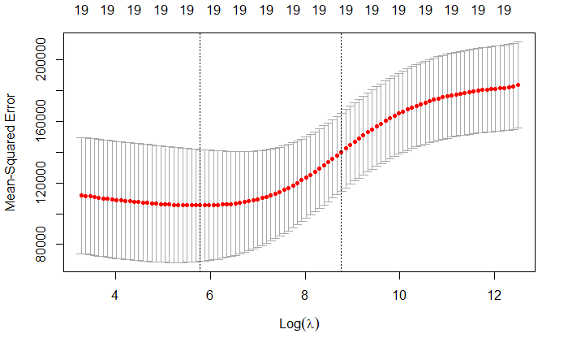

```r
set.seed(1)
cv.out=cv.glmnet(x[train,], y[train], alpha=0)
plot(cv.out)
```

```r
bestlam=cv.out$lambda.min
bestlam
```

```
[1] 326.0828
```

```r
ridge.pred=predict(ridge.mod,s=bestlam,newx=x[test,])
mean((ridge.pred-y.test)^2)
```

```
[1] 139856.6
```

```r
out=glmnet(x,y,alpha=0)
predict(out,type="coefficients", s=bestlam) [1:20,]
```

```
 (Intercept)        AtBat         Hits        HmRun         Runs          RBI        Walks
 15.44383135   0.07715547   0.85911581   0.60103107   1.06369007   0.87936105   1.62444616
       Years       CAtBat        CHits       CHmRun        CRuns         CRBI       CWalks
  1.35254780   0.01134999   0.05746654   0.40680157   0.11456224   0.12116504   0.05299202
     LeagueN    DivisionW      PutOuts      Assists       Errors   NewLeagueN
 22.09143189 -79.04032637   0.16619903   0.02941950  -1.36092945   9.12487767
```

We improved over lambda=4. We also refit the ridge regression into the full data set using the value of lambda chosen by CV. None of our coefficients are 0!